# Election Prediction

Graham Tierney

10/11/2020

```
## Linked to JAGS 4.3.0
```

```
## Loaded modules: basemod,bugs
```

## Set up data

Here we load the polling data and drop duplicate questions.

```r
polls <- read_excel("data/2016_Economist_Polls.xlsx") %>%
  filter(population %in% c("Likely Voters","Registered Voters"),question.iteration == 1) %>%
  mutate(days_to_election = as.Date("2016-11-08") - as.Date(end.date),
         state = ifelse(state == "--","US",state),
         y = clinton/(clinton + trump)*100)
```

```
## * `` -> ...1
```

```r
### EXERCISE: filter polls to only polls 100 days or fewer before the election and the following states: US,WI,OH,PA,NC,FL,VA
polls <- polls %>%
  filter(days_to_election <= 100,state %in% c("US","WI","OH","PA","NC","FL","VA"))
```

## Create data list

JAGS and Stan neeed the data passed in as a named list. Create that here. Some have been filled in for you

```r
states <- polls$state %>% unique
y <- polls$y
r <- match(polls$state,states)
t <- polls$days_to_election + 1 #WHY PLUS ONE?
N_polls <- y %>% length
N_states <- states %>% length
N_days <- t %>% max
jags_data <- list(y=y,t=t,r=r,
                  N_polls=N_polls,N_states=N_states,N_days=N_days)
```

## Write model

The model we will use is $Y_k$, Clinton’s share of the two-party vote, is normally distributed with mean $\beta_{jt}$, where the poll ended $t$ days before the election and was conducted on population $j$. Each state has its own observation variance, $\sigma^2_{yj}$ and two-party preferences. Thus, $Y_k \sim N(\beta_{jt},\sigma^2_{yh})$. We use a random walk for $\beta$, $\beta_{jt} \sim N(\beta_{jt-1},\sigma^2_{\beta j})$. We will let other states influence each other by placing a hierarchical prior on the model parameters: $\{\sigma^2_{yj},\sigma^2_{\beta j},\beta_{j1}\}$. $\sigma^2_{yj} \sim P_{\sigma_y}$; $\sigma^2_{\beta j} \sim P_{\sigma_\beta}$; $\beta_{j1} \sim P_\beta$. In the code below, everything is set up EXCEPT these hierarchical structures. You can choose whatever distributions $P$ you like.

```r
model <- function(){
  for(k in 1:N_polls){
    y[k] ~ dnorm(p[k],1/sigma2_y[r[k]]) #note no longer binomial
    p[k] = beta[r[k],t[k]]
  }
  for(j in 2:N_days){
    for(i in 1:N_states){
      beta[i,j] ~ dnorm(beta[i,j-1],pow(sigma2_beta[i],-1))
    }
  }

  #EXERCISE: add hierarchical prior for sigma2_beta and sigma2_y, i.e. sigma2_beta[j] all come from a common distribution
  for(j in 1:N_states){
      sigma2_y[j] = 1/sigma2_y_inv[j]
      sigma2_y_inv[j] ~ dgamma(nu_y,nu_y*tau_y)

      sigma2_beta[j] = 1/sigma2_beta_inv[j]
      sigma2_beta_inv[j] ~ dgamma(nu_beta,nu_beta*tau_beta)

      beta[j,1] ~ dnorm(mu0,pow(sigma2_0,-1))
  }
  nu_y ~ dunif(0,100)
  tau_y ~ dunif(0,100)

  nu_beta ~ dunif(0,100)
  tau_beta ~ dunif(0,100)

  mu0 ~ dnorm(50,pow(7.5,-2))
  sigma2_0 = 1/sigma2_0_inv
  sigma2_0_inv ~ dgamma(.5,.5)
}
```

## Run and analyze results

```r
#be sure to add your added parameters to parameters.to.save
jags_sims <- jags(data = jags_data,model.file = model,parameters.to.save = c("beta","sigma2_beta",
                                                                             "p","sigma2_y"),
                  n.iter = 10000)
```

```
## module glm loaded
```

Now, lets look at some results.

1. For one or two states, plot the expected value of a poll of that state ($\beta_{jt}$), 95% CIs, and observed poll results. Does your model look good?
2. Compare the implied binomial variance $p(1-p)/n$ to the estimated variance $\sigma^2_{yj}$ for one or two states. Do the quantities look similar?
3. Who do you predict is the winner in each state? Give a forecast electoral college vote split by awarding all non-modeled results to the actual winner. EC votes: US-0, FL-29, NC-15, OH-18, PA-20, VA-13, WI-10.
4. How does the probability of winning one state affect another? Estimate P(Clinton wins NC) and P(Clinton wins NC|Clinton loses OH), or pick your own pair of states. Are the probabilities different? Should they be?
5. Finally, try removing all data from the final month of the campaign from `jags_data`, then re-estimate the model. Do your predictions change?

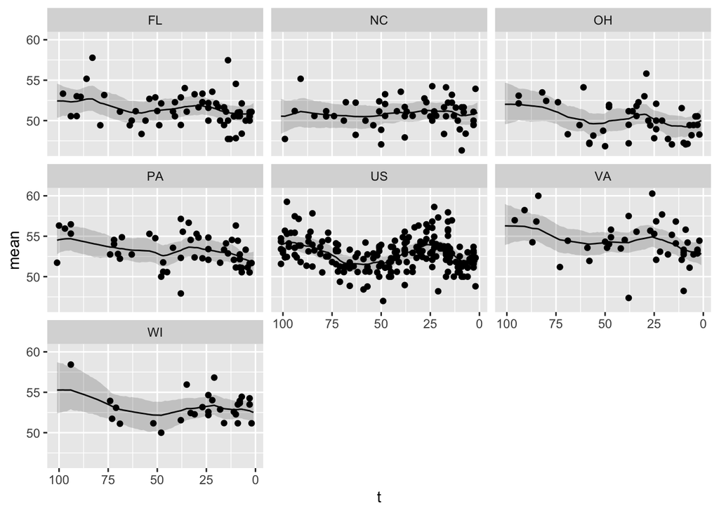

```r
## problem 1
poll_plot_data <- tibble(y=jags_data$y,t=jags_data$t %>% as.integer(),state = states[jags_data$r])
beta_plot_data <- lapply(1:N_states,function(st){
  sims <- jags_sims$BUGSoutput$sims.list$beta[,st,]
  data.frame(state = states[st],t=1:N_days,mean=colMeans(sims),lb=apply(sims,2,quantile,probs=.025),ub=apply(sims,2,quantile,probs=.975))
}) %>%
  bind_rows()
left_join(beta_plot_data,poll_plot_data) %>%
  ggplot(aes(x=t)) +
  geom_line(aes(y=mean)) +
  geom_ribbon(aes(ymin = lb,ymax = ub),alpha = .2) +
  geom_point(aes(y=y)) +
  scale_x_reverse() +
  facet_wrap(~ state)
```

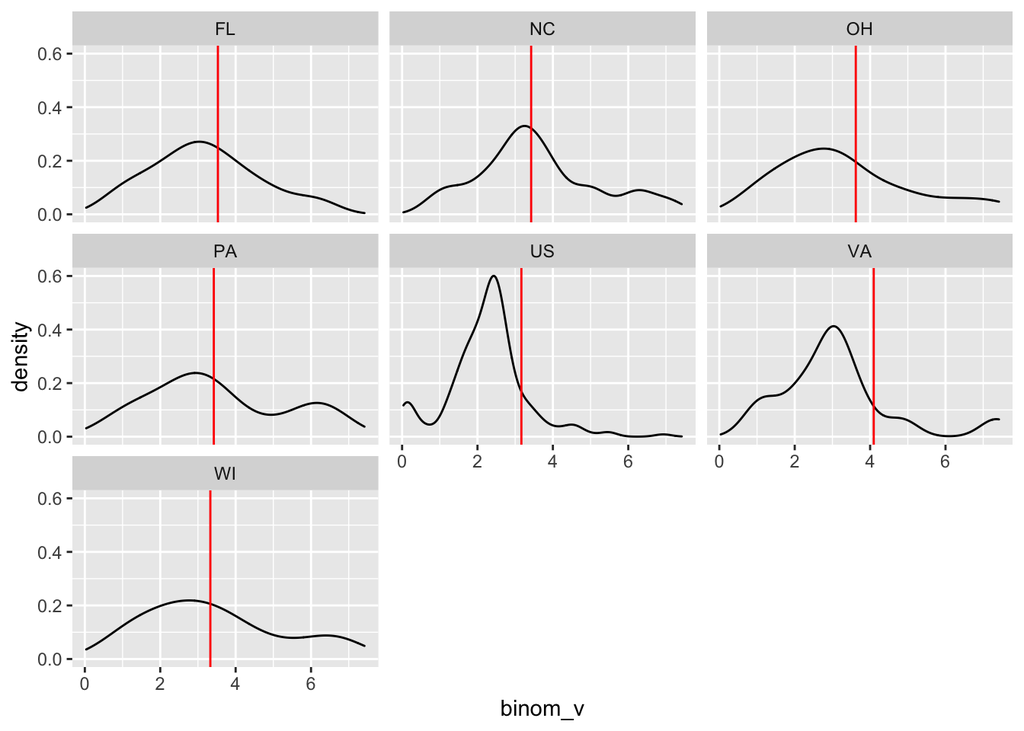

```r
# problem 2
poll_plot_data$p <- jags_sims$BUGSoutput$mean$p
poll_plot_data$sigma2y <- jags_sims$BUGSoutput$mean$sigma2_y[jags_data$r]
poll_plot_data$binom_v <- (poll_plot_data$p)*(100-poll_plot_data$p)/as.numeric(polls$number.of.observations)
poll_plot_data %>%
  ggplot(aes(x=binom_v)) +
  geom_density() +
  geom_vline(aes(xintercept = sigma2y),color = "red") +
  facet_wrap(~ state)
```

```r
# problem 3
elec_sims <- jags_sims$BUGSoutput$sims.list$beta[,,1]
colnames(elec_sims) <- states
(elec_sims>50) %>% colMeans() #P(Clinton Win) each state
```

```
##        US        FL        NC        OH        PA        VA        WI
## 1.0000000 0.9433333 0.9340000 0.5046667 0.9986667 1.0000000 1.0000000
```

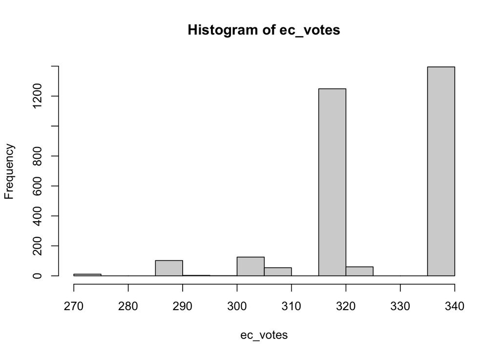

```r
#in other states: Clinton: 232-13, Trump: 306-29-18-15-10-20
c_ex_votes <- 232-13; t_ex_votes <- 306-29-18-15-10-20
ec_votes <- ((elec_sims>50) %*% diag(c(0,29,15,18,20,13,10))) %>% rowSums() + 232
hist(ec_votes)
```

```r
mean(ec_votes>=270)
```

```
## [1] 1
```

```r
# problem 4
sims <- jags_sims$BUGSoutput$sims.list$beta[,,1]
colnames(sims) <- states
sims %>% {.>50} %>% colMeans() #independent probs
```

```
##        US        FL        NC        OH        PA        VA        WI
## 1.0000000 0.9433333 0.9340000 0.5046667 0.9986667 1.0000000 1.0000000
```

```r
sims[sims[,4]<50,] %>% {.>50} %>% colMeans() #conditional probs
```

```
##        US        FL        NC        OH        PA        VA        WI
## 1.0000000 0.9239569 0.9098250 0.0000000 0.9986541 1.0000000 1.0000000
```

```r
# problem 5
make_data <- function(data){
  states <- data$state %>% unique
  y <- data$y
  r <- match(data$state,states)
  t <- data$days_to_election + 1 #WHY PLUS ONE?

  N_polls <- y %>% length
  N_states <- states %>% length
  N_days <- t %>% max

  jags_data <- list(y=y,t=t,r=r,
                    N_polls=N_polls,N_states=N_states,N_days=N_days)

  return(jags_data)
}
jags_data_1mo <- make_data(polls %>% filter(days_to_election>=30))
jags_sims_1mo <- jags(data = jags_data_1mo,model.file = model,parameters.to.save = c("beta","sigma2_beta",
                                                                             "p","sigma2_y"),
                  n.iter = 10000)
```

```
## module glm loaded
```

```r
elec_1mo <- jags_sims_1mo$BUGSoutput$sims.list$beta[,,1]
colnames(elec_1mo) <- states
(elec_1mo>50) %>% colMeans() #P(Clinton Win) each state
```

```
##        US        FL        NC        OH        PA        VA        WI
## 0.9893333 0.9893333 0.9636667 0.9316667 0.9996667 0.9970000 0.9880000
```

## Bonus: Multivariate

Now, instead of having all states equally correlated with each other via the hierarchy, we will estimate the correlation structure. Now $Y_k \sim N(\theta_{jt},\sigma^2_{yj})$. The evolution is as follows:

$$\theta_{\cdot t} \sim MVN(\theta_{\cdot t-1},\Sigma)$$

Using same priors on $\theta_{\cdot 1}$, the day of the election, as before, rewrite the jags code to implement the above model.

```r
model_mv <- function(){
  for(k in 1:N_polls){
    y[k] ~ dnorm(p[k],1/sigma2_y[r[k]]) #note no longer binomial
    p[k] = theta[r[k],t[k]]
  }
  for(j in 2:N_days){
    theta[1:N_states,j] ~ dmnorm(theta[1:N_states,j-1],Phi)
  }
  Phi ~ dwish(I_states,N_states+1) #fill in wishart parameters, google JAGS wishart distribution should turn it up
  Sigma = inverse(Phi)
  #which, Phi or Sigma is the covariance and which is the precision?

  #optional: theta[1:N_states,1] ~ dmnorm(mu0,s0) #define mu0 and s0 in your jags_data object

  #Use your hierarhciacl prior for sigma2_y from before
  for(j in 1:N_states){
      sigma2_y[j] = 1/sigma2_y_inv[j]
      sigma2_y_inv[j] ~ dgamma(nu_y,nu_y*tau_y)

      theta[j,1] ~ dnorm(mu0,pow(sigma2_0,-1))
  }
  nu_y ~ dunif(0,100)
  tau_y ~ dunif(0,100)

  nu_beta ~ dunif(0,100)
  tau_beta ~ dunif(0,100)

  mu0 ~ dnorm(50,pow(7.5,-2))
  sigma2_0 = 1/sigma2_0_inv
  sigma2_0_inv ~ dgamma(.5,.5)
}
```

Re-estimate the model.

```r
jags_data$I_states <- diag(N_states)
#be sure to add your added parameters to parameters.to.save
jags_sims_mv <- jags(data = jags_data,model.file = model_mv,parameters.to.save = c("theta","Sigma",
                                                                                "p","sigma2_y"),
                  n.iter = 10000)
```

Now, how does the probability of winning one state affect another? Estimate P(Clinton wins NC) and P(Clinton wins NC|Clinton loses OH), or pick your own pair of states. Are the probabilities different?

```r
sims <- jags_sims_mv$BUGSoutput$sims.list$theta[,,1]
colnames(sims) <- states
sims %>% {.>50} %>% colMeans()
```

```
##        US        FL        NC        OH        PA        VA        WI
## 0.9960000 0.8940000 0.9240000 0.5840000 0.9853333 0.9960000 0.9926667
```

```r
sims[sims[,4]<50,] %>% {.>50} %>% colMeans()
```

```
##        US        FL        NC        OH        PA        VA        WI
## 0.9935897 0.8325321 0.8870192 0.0000000 0.9759615 0.9911859 0.9887821
```

Try to visualize the correlation matrix. The `get_heatmap` function below will take a correlation matrix and make a heatmap.

```r
reorder_cormat <- function(cormat){
  # Use correlation between variables as distance
  dd <- as.dist((1-cormat)/2)
  hc <- hclust(dd)
  cormat <-cormat[hc$order, hc$order]
}
get_upper_tri <- function(cormat){
  cormat[lower.tri(cormat)]<- NA
  return(cormat)
}
get_heatmap <- function(cormat){
  cormat %>%
    cov2cor() %>%
    reorder_cormat %>%
    get_upper_tri %>%
    reshape2::melt(na.rm = TRUE) %>%
    ggplot(aes(Var2, Var1, fill = value))+
    geom_tile(color = "white")+
    scale_fill_gradient2(low = "blue", high = "red", mid = "white",
                         midpoint = 0, limit = c(-1,1), space = "Lab",
                         name="Pearson\nCorrelation") +
    theme_minimal()+ # minimal theme
    labs(x="",y="") +
    theme(axis.text.x = element_text(angle = 45, vjust = 1,
                                     size = 12, hjust = 1))+
    coord_fixed()
}
```

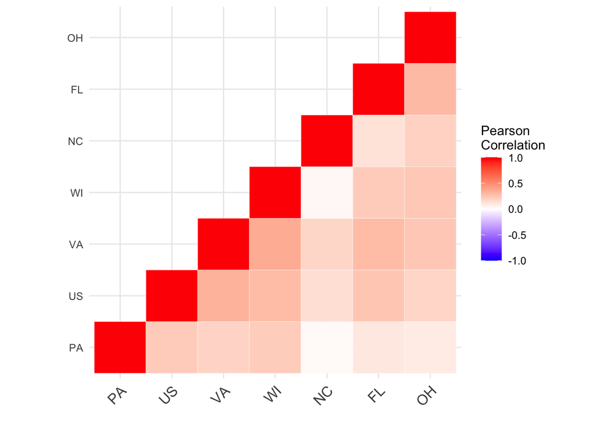

```r
cor_sims <- array(NA,dim = jags_sims_mv$BUGSoutput$sims.list$Sigma %>% dim)
for(i in 1:dim(cor_sims)[1]){
  cor_sims[i,,] <- cov2cor(jags_sims_mv$BUGSoutput$sims.list$Sigma[i,,])
}
cor_mean <- apply(cor_sims,c(2,3),mean)
colnames(cor_mean) <- states
rownames(cor_mean) <- states
#full heatmap
get_heatmap(cor_mean)
```